# Linear Regression

Elsa Marques

12/11/2017

## 0.1 - Linear regresssion

Linear regression allows you to test the relationship between a target variable and one (simple linear regression) or more explanatory variables (multiple linear regression). With this analysis you can read how the variables relate or not with which others, either positively or negatively related or not at all.

- To explore the previously mentioned hypothesis I check if there is any relationship between the Number of Activities and Age, Profession, Marital Status and Gender.

```
##
## Call:
## lm(formula = N.Act ~ Age + Prof + Gender + Marital.St, data = Hobbies)
##
## Residuals:
##     Min      1Q  Median      3Q     Max
## -9.6291 -2.2056 -0.1606  2.1427 10.8280
##
## Coefficients:
##                      Estimate Std. Error t value Pr(>|t|)
## (Intercept)           7.18105    0.15491  46.357  < 2e-16 ***
## Age(35,45]            0.03689    0.12218   0.302 0.762708
## Age(45,55]           -0.41556    0.12434  -3.342 0.000836 ***
## Age(55,65]           -0.93112    0.13795  -6.750 1.60e-11 ***
## Age(65,75]           -1.74063    0.15527 -11.210  < 2e-16 ***
## Age(75,85]           -2.82699    0.20029 -14.115  < 2e-16 ***
## Age(85,100]          -3.76194    0.41748  -9.011  < 2e-16 ***
## Age[15,25]            0.09331    0.17290   0.540 0.589430
## ProfForeman           1.44779    0.13015  11.124  < 2e-16 ***
## ProfManagement        2.38660    0.11727  20.351  < 2e-16 ***
## ProfManual labourer  -0.67695    0.11751  -5.761 8.73e-09 ***
## ProfOther             0.54573    0.21738   2.510 0.012080 *
## ProfTechnician        0.64751    0.16948   3.821 0.000134 ***
## ProfUnskilled worker -1.53323    0.12665 -12.106  < 2e-16 ***
## GenderM              -0.47033    0.08415  -5.589 2.37e-08 ***
## Marital.StMarried     0.25697    0.12499   2.056 0.039830 *
## Marital.StRemarried   0.56212    0.19800   2.839 0.004540 **
## Marital.StSingle      0.49490    0.15031   3.292 0.000998 ***
## Marital.StWidower     0.03366    0.18166   0.185 0.853017
## ---
## Signif. codes:  0 '***' 0.001 '**' 0.01 '*' 0.05 '.' 0.1 ' ' 1
##
## Residual standard error: 3.023 on 6886 degrees of freedom
## Multiple R-squared:  0.1943, Adjusted R-squared:  0.1922
## F-statistic: 92.27 on 18 and 6886 DF,  p-value: < 2.2e-16
```

### 0.1.1 Let’s analyse case by case with the help of graphs for visualization of the variables in question:

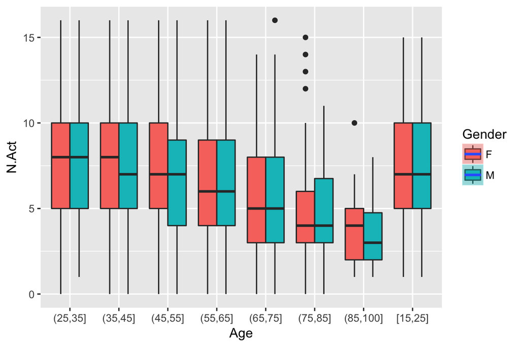

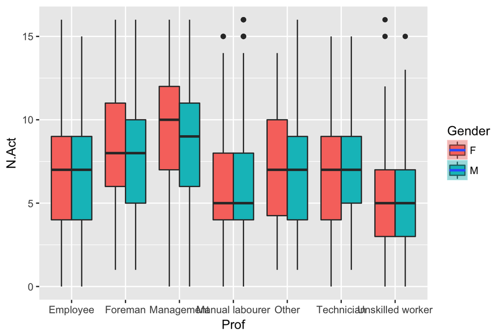

```r
library(ggplot2)
p2 <- ggplot(data = Hobbies, aes(y = N.Act, x = Prof , fill = Gender)) + geom_boxplot() + geom_smooth(method = "lm")
p2
```

- When it comes to Profession, the number of activitees varies less regarding the gender of the inquires. Only in the management profession one could verify that females are still able to maintain an higher amount of hobbies, comparing to the males with the same profession. This is also the profession (from the ones that were accessed) were we can verify the highest average of activitees undertaken by the enquired. The average amount of hobbies seems more related to your salary or to the amount of physical work you undertake in your job, which means you either have less money to undertaken in several hobbies or you have less energy to do so. As you can verify that unskilled and manual labourer present the lower average number of hobbies.

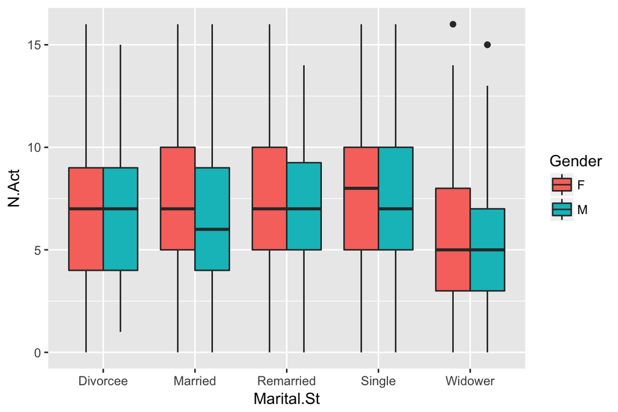

### 0.1.2 Graphical model validation

We might want to check how our linear model actually can be validate by using graphical analysis. Residuals Vs Fitted; Normal Q-Q and Residuals Vs Leverage graphs are used for this purpose:

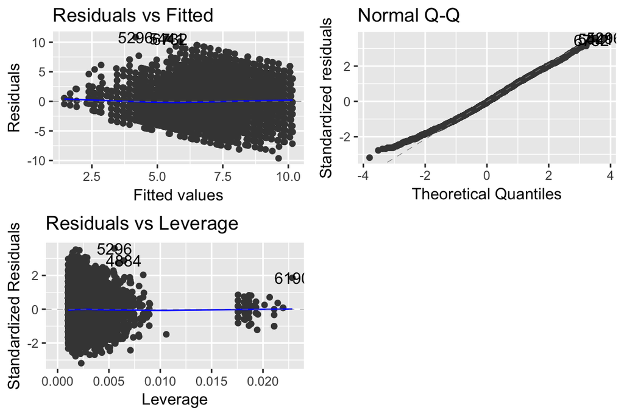

```r
#Graphical model validation
library(ggfortify)

autoplot(hobbies_model, which= c(1, 2, 5)) +
     theme_gray()
```

- Residuals Vs Fitted:

By definition: “Residuals versus fits plot is a scatter plot of residuals on the y axis and fitted values (estimated responses) on the x axis. The plot is used to detect non-linearity, unequal error variances, and outliers.”

- Normal Q-Q:

By definition: “If the two distributions being compared are similar, the points in the Q–Q plot will approximately lie on the line y = x. If the distributions are linearly related, the points in the Q–Q plot will approximately lie on a line, but not necessarily on the line y = x.” “A normal Q–Q plot comparing randomly generated, independent standard normal data on the vertical axis to a standard normal population on the horizontal axis. The linearity of the points suggests that the data are normally distributed.”

- Residuals Vs Leverage:

By definition: “Outliers: an outlier is defined as an observation that has a large residual. In other words, the observed value for the point is very different from that predicted by the regression model. Leverage points: A leverage point is defined as an observation that has a value of x that is far away from the mean of x.”